# Elaborar un gráfico de puntos en Python

En este post vamos crear un gráfico de puntos, llamado scatters.

Tenemos una base de datos ordenada que conocimos en Datacamp y está en su nube. Esta base contiene la información de 392 automóviles fabricados entre 1970 y 1982.

Un gráfico de puntos nos ayuda visualmente a tener una idea de la relación entre dos variables. En este ejemplo las dos variables que graficaremos serán: la eficiencia en el consumo de combustible y los caballos de fuerza.

Queremos saber si tienen **(1)** una relación directa (entre más caballos de fuerza mejor eficiencia en consumo de combustible), **(2)** inversa (más caballos de fuerza sacrifica la eficiencia en el consumo de combustible), **(3)** o no tiene relación (puntos muy dispersos que no permiten definir alguna relación entre caballos de fuerza y eficiancia en el consumo de combustible).

Pasos:

--Importar la base de datos. Está en la nube en formato CSV. Podemos importar un archivo CSV con la librería pandas.

```python
import pandas as pd
```

```python
datos = pd.read_csv('https://assets.datacamp.com/production/course_1639/datasets/auto-mpg.csv')
```

--Explorar la base importada.

```python
print(datos.info())
```

```
<class 'pandas.core.frame.DataFrame'>
RangeIndex: 392 entries, 0 to 391
Data columns (total 9 columns):
mpg       392 non-null float64
cyl       392 non-null int64
displ     392 non-null float64
hp        392 non-null int64
weight    392 non-null int64
accel     392 non-null float64
yr        392 non-null int64
origin    392 non-null object
name      392 non-null object
dtypes: float64(3), int64(4), object(2)
memory usage: 27.6+ KB
None
```

*Tiene 392 observaciones por cada variables.

*9 columnas que son las 9 variables que posee.

*No posee valores perdidos.

```python
print(datos.shape)
```

```
(392, 9)
```

```python
datos.head(10)
```

|  | mpg | cyl | displ | hp | weight | accel | yr | origin | name |
| --- | --- | --- | --- | --- | --- | --- | --- | --- | --- |
| 0 | 18.0 | 8 | 307.0 | 130 | 3504 | 12.0 | 70 | US | chevrolet chevelle malibu |
| 1 | 15.0 | 8 | 350.0 | 165 | 3693 | 11.5 | 70 | US | buick skylark 320 |
| 2 | 18.0 | 8 | 318.0 | 150 | 3436 | 11.0 | 70 | US | plymouth satellite |
| 3 | 16.0 | 8 | 304.0 | 150 | 3433 | 12.0 | 70 | US | amc rebel sst |
| 4 | 17.0 | 8 | 302.0 | 140 | 3449 | 10.5 | 70 | US | ford torino |
| 5 | 15.0 | 8 | 429.0 | 198 | 4341 | 10.0 | 70 | US | ford galaxie 500 |
| 6 | 14.0 | 8 | 454.0 | 220 | 4354 | 9.0 | 70 | US | chevrolet impala |
| 7 | 14.0 | 8 | 440.0 | 215 | 4312 | 8.5 | 70 | US | plymouth fury iii |
| 8 | 14.0 | 8 | 455.0 | 225 | 4425 | 10.0 | 70 | US | pontiac catalina |
| 9 | 15.0 | 8 | 390.0 | 190 | 3850 | 8.5 | 70 | US | amc ambassador dpl |

*Notamos que name es la marca específica de vehículos.

--Las variables a graficar son **hp** ("caballos de fuerza") y **mpg** ("Eficiencia en Consumo de combustible)

```python
lista = ['hp', 'mpg']
datos[lista].describe() #Ejecuto si quiero conocer los estadísticos de las dos variables
```

|  | hp | mpg |
| --- | --- | --- |
| count | 392.000000 | 392.000000 |
| mean | 104.469388 | 23.445918 |
| std | 38.491160 | 7.805007 |
| min | 46.000000 | 9.000000 |
| 25% | 75.000000 | 17.000000 |
| 50% | 93.500000 | 22.750000 |
| 75% | 126.000000 | 29.000000 |
| max | 230.000000 | 46.600000 |

--Importar la librería gráfica matplotlib y numpy. Además quiero ver que tanto corresponde el peso al resultado gráfico que obtendré. Me genero un array con **weight** pero tendré primero que normalizarla.

```python
import matplotlib.pyplot as plt
import numpy as np
%matplotlib inline
```

```python
sizes = datos.weight/(datos.weight.max()/350)#normalizando
```

--Graficar:

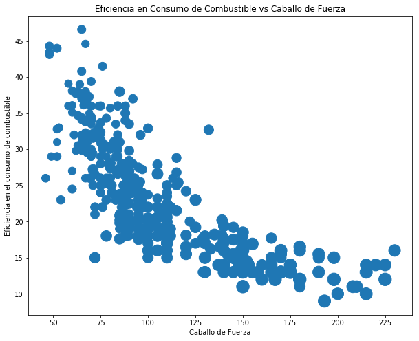

```python
datos.plot(kind='scatter', x='hp', y='mpg', s=sizes) #s es el tamaño de los puntos.
plt.title('Eficiencia en Consumo de Combustible vs Caballo de Fuerza') #title agrega un título
plt.xlabel('Caballo de Fuerza') #Define la etiqueta de x
plt.ylabel('Eficiencia en el consumo de combustible') #Define la etiqueta de y
plt.rcParams["figure.figsize"] =(10,8) #Darle un tamaño adecuado
plt.show()
```

Hasta aquí vamos a dejar la creación del scatter. Continuaremos en los próximos post configurando scatter con opciones avanzadas como agregar, colores, transparencias, etiquetas a los puntos, etc.

Regresando al gráfico, podemos comentar que Eficiencia y Caballos de Fuerza tiene una relación inversa, quiere decir que los vehículos con más caballos de fuerza son los menos eficientes con el consumo de combustible.